Don't let their slow movement fool you, sea stars are an important part of kelp forests. Some are fierce predators, while others are vital decomposers.

### PISCO: Sea Stars on Islands

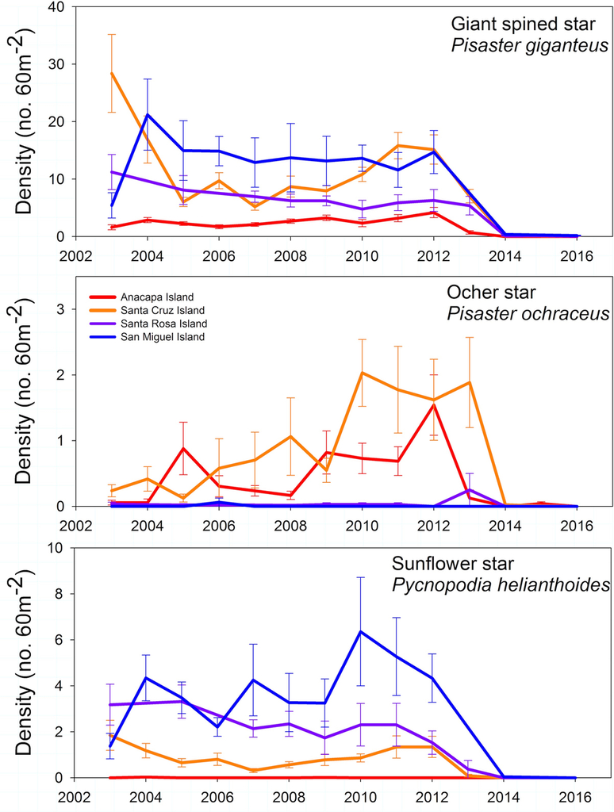

A figure showing the amount of three important sea stars at 14 different sites acros the four northern Channel Islands from 2003 to 2016. Data source: PISCO; Figure credit: [R. Freedman/NOAA](https://channelislands.noaa.gov/contact/freedman.html).

**Click for Details**

Average density (+/- standard error) of giant spined star (*Pisaster giganteus*) (top), ochre star (*P. ochraceus*) (middle) and sunflower star (*Pycnopodia helianthoides*) (bottom) at 14 sites across four islands in Channel Islands National Marine Sanctuary monitored by the PISCO kelp forest monitoring program from 2003â€“2016. Sea stars are counted by SCUBA divers swimming along transect lines. Sea star density was averaged across all monitoring sites at each island, including sites located inside and outside of marine reserves and conservation areas, to examine course-scale trends by island. Giant, ochre, and sunflower stars suffered severe declines from 2013 to 2014 at all four islands due to sea star wasting syndrome. For more information, consult Figure App.F.12.7 in the [CINMS 2016 Condition Report](https://nmssanctuaries.blob.core.windows.net/sanctuaries-prod/media/docs/2016-condition-report-channel-islands-nms.pdf).

### NPS: Giant-spined star

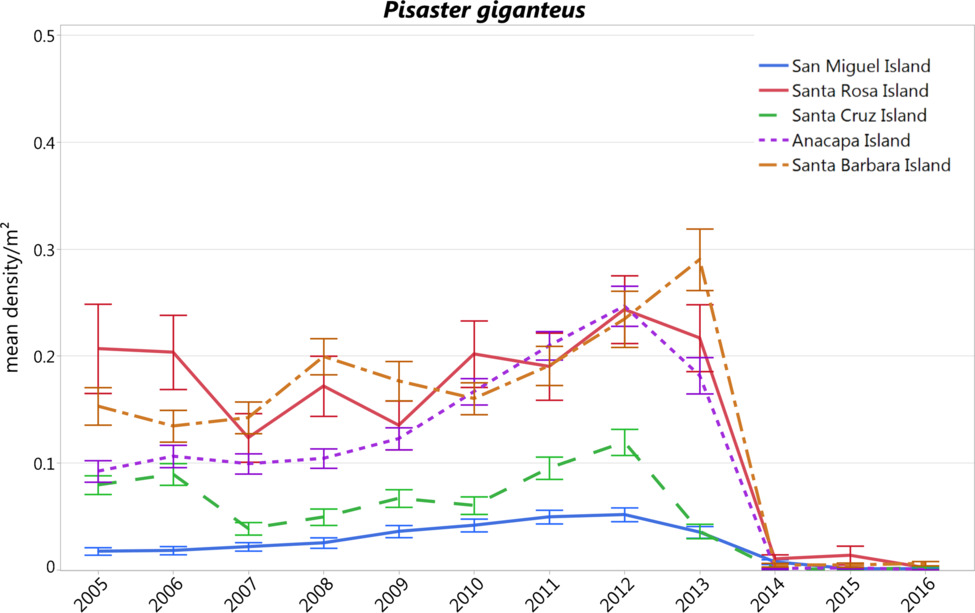

A figure showing the amount of giant-spined sea stars across all of the northern Channel Islands from 2005 to 2016. Figure credit: [Channel Islands National Park](https://www.nps.gov/chis/index.htm).

**Click for Details**

Average density (+/- standard error) of the giant-spined star (*Pisaster giganteus*) at Channel Islands National Park kelp forest monitoring sites at the five islands in CINMS. Sea stars are counted by SCUBA divers. Sea star density was averaged across all monitoring sites at each island, including sites located inside and outside of marine reserves and conservation areas, to examine course-scale trends by island. Sea star abundance drastically declined at all islands prior to 2014 monitoring and have remained very low through 2016. For more information, consult Figure App.F.12.8a in the [CINMS 2016 Condition Report](https://nmssanctuaries.blob.core.windows.net/sanctuaries-prod/media/docs/2016-condition-report-channel-islands-nms.pdf).

### LTER: Sea stars

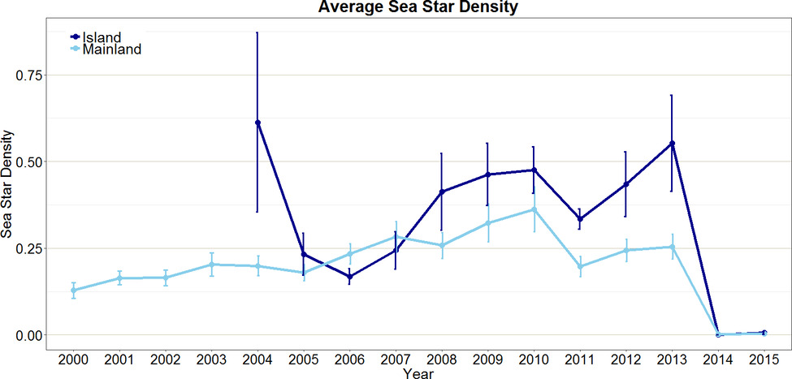

A figure showing the mount of ochre and sunflower stars on two of the Channel Islands (dark blue) and at nine mainland (light blue) kelp forests sites from 2000 to 2015. Data source: SBC LTER; Figure credit: [R. Freedman/NOAA](https://channelislands.noaa.gov/contact/freedman.html).

**Click for Details**

Average density (+/- standard error) of sea stars (*Pisaster* and *Pycnopodia* combined) at two island (dark blue) and nine mainland (light blue) kelp forest sites monitored by the Santa Barbara Channel Long-term Ecological Research (SBC LTER) program. Sea star density had drastically declined all sites prior to 2014 monitoring and remained very low through 2015. For more information, consult Figure App.F.12.9 in the [CINMS 2016 Condition Report](https://nmssanctuaries.blob.core.windows.net/sanctuaries-prod/media/docs/2016-condition-report-channel-islands-nms.pdf).

### NPS: Sunflower star

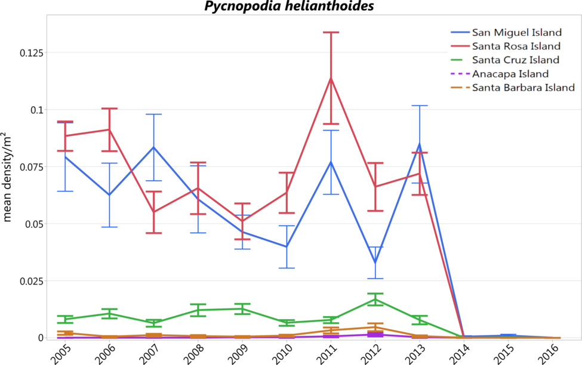

A figure showing the amount of sunflower stars across all of the northern Channel Islands from 2005 to 2016. Figure credit: [Channel Islands National Park](https://www.nps.gov/chis/index.htm).

**Click for Details**

Average density (+/- standard error) of the sunflower star (*Pycnopodia helianthoides*) at Channel Islands National Park kelp forest monitoring sites at the five islands in CINMS. Sea stars are counted by SCUBA divers. Sea star density was averaged across all monitoring sites at each island, including sites located inside and outside of marine reserves and conservation areas, to examine course-scale trends by island. Sea star abundance drastically declined at all islands prior to 2014 monitoring and have remained very low through 2016. For more information, consult Figure App.F.12.8b in the [CINMS 2016 Condition Report](https://nmssanctuaries.blob.core.windows.net/sanctuaries-prod/media/docs/2016-condition-report-channel-islands-nms.pdf).